# C3하지혜_종합실습1

종합실습1

- 분석 배경: 미세먼지로 인해 건강, 환경, 경제 등 영향을 주면서 다양한 문제를 일으키고 있다. 그래서 대기 중 오염물질과 기상정보를 활용하여 미세먼지 발생/증가에 영향을 미치는 인자를 도출하고 그 영향도를 분석하려 한다.
1. 데이터 불러오기
2. 탐색적 분석 및 통계분석
3. 회귀분석
4. 랜덤 포레스트
5. 그래디언트 부스팅
6. 영향인자 선정 및 결과 해석

순으로 진행하려 한다.  
ㅡㅡㅡㅡㅡㅡㅡㅡㅡㅡㅡㅡㅡㅡㅡㅡㅡㅡㅡㅡ

1. 기술통계량 describe / 결측치확인 -> PM10은 목표변수로 적절한 결측값 확인 불가하므로 삭제, C0: 목표변수에 대한 영향 확인 후 결정  
   산점도로 PM10, C0 관계 확인-> 우상향하는 느낌

C0: 평균/중앙값 대체는 증가값이라 위험... transform어쩌구로 함

히스토그램으로 분포 보고 해석 + boxplot으로 이상치확인(표준화(scale)할것인가도 생각) + plot line (시계열) 그려서 확인 + 산점도(첫번째 변수와의 산점도는 안 나옴) + pairplot

- 상관분석: corr, CO가 높다 ? 목표변수와 상관관계 높은 변수 정렬(sort_values),
1. 회귀분석 회귀계수 표 그래서 + - 구분하고
2. 돌리고
3. 돌리고

돌릴때 무슨 인자가 중요한지 기록하기.

1. 결과 정리 + 개선안(미세먼지 발생ㅇ을 방지하려면 ㅇㅇㅇ를 해야한다)

## 과제 정의

https://www.me.go.kr/mamo/web/index.do?menuId=587

https://www.air.go.kr/index.do

MeasDate 측정일자 제외 연속형  
PM10 미세먼지10㎍/㎥ 목표변수 연속형  
O3 오존 농도 설명변수 연속형  
NO2 이산화질소 농도 설명변수 연속형  
CO 일산화탄소 농도 설명변수 연속형  
SO2 아황산가스 농도 설명변수 연속형  
TEMP 기온(°C) 설명변수 연속형  
RAIN 강수량(mm) 설명변수 연속형  
WIND 풍속(m/s) 설명변수 연속형  
WIND_DIR 풍향(16방위) 설명변수 연속형  
HUMIDITY 습도(%) 설명변수 연속형  
ATM_PRESS 현지기압(hPa) 설명변수 연속형  
SNOW 적설(cm) 설명변수 연속형  
CLOUD 전운량(10분위) 설명변수 연속형

```python
import pandas as pd
import matplotlib
import matplotlib.pyplot as plt
import seaborn as sns
import numpy as np

# Scale 변환-> 설명변수 변환 : 회귀분석.설명변수 회귀계수 표준화
from sklearn.preprocessing import StandardScaler

# train, test 데이터 분할 함수
from sklearn.model_selection import train_test_split

# 회귀모델
import statsmodels.formula.api as smf
import statsmodels.api as sm

# 선형회귀모형
from sklearn.linear_model import LinearRegression

# 다중공선성 확인
from statsmodels.stats.outliers_influence import variance_inflation_factor

# 변수 선택법(후진제거법)
from sklearn.feature_selection import RFE

# 평가 함수
from sklearn.metrics import r2_score
from sklearn.metrics import mean_squared_error
from sklearn.metrics import mean_absolute_error
from sklearn.metrics import mean_absolute_percentage_error

# RMSE: root mean squared error 함수
def root_mean_squared_error(y_true, y_pred):
    return np.sqrt(mean_squared_error(y_true, y_pred))

# MAPE: mean absolute percentage error 함수
def mean_absolute_percentage_error(y_true, y_pred):
    return np.mean(np.abs((y_true - y_pred) / y_true)) * 100

# 평가 리스트 초기화
mse, rmse, mae, mape = [], [], [], []

# 모델 리스트, 그래프를 그리기 생성 목적
models = ["회귀분석", "의사결정나무", "랜덤 포레스트", "그래디언트 부스팅"]
```

```python
# 옵션 지정
pd.options.display.precision = 2

# 한글 폰트
matplotlib.rc('font', family='NanumGothic')
matplotlib.rcParams['axes.unicode_minus'] = False
plt.rcParams["font.family"] = 'NanumGothic'
```

## 데이터 처리

```python
df_raw = pd.read_csv("../빅데이터 기초/Data/AIR_POLLUTION.csv", parse_dates=["MeasDate"])  # 날짜를 datatime 형식으로 지정
print("shape: ", df_raw.shape)

df_raw
```

```
shape:  (366, 14)
```

|  | MeasDate | PM10 | O3 | NO2 | CO | SO2 | TEMP | RAIN | WIND | WIND_DIR | HUMIDITY | ATM_PRESS | SNOW | CLOUD |
| --- | --- | --- | --- | --- | --- | --- | --- | --- | --- | --- | --- | --- | --- | --- |
| 0 | 2019-07-01 | 29.0 | 0.05 | 2.10e-02 | 0.5 | 3.00e-03 | 24.03 | 0.00 | 2.30 | 249 | 63.2 | 995.1 | 0.0 | 5.70 |
| 1 | 2019-07-02 | 26.0 | 0.05 | 2.00e-02 | 0.5 | 3.00e-03 | 24.29 | 0.00 | 2.26 | 265 | 63.2 | 998.6 | 0.0 | 3.83 |
| 2 | 2019-07-03 | 30.0 | 0.04 | 2.30e-02 | 0.4 | 3.00e-03 | 24.18 | 0.00 | 1.79 | 280 | 65.3 | 998.3 | 0.0 | 6.29 |
| 3 | 2019-07-04 | 28.0 | 0.03 | 2.60e-02 | 0.4 | 3.00e-03 | 25.35 | 0.00 | 2.04 | 263 | 58.6 | 996.6 | 0.0 | 2.54 |
| 4 | 2019-07-05 | 29.0 | 0.04 | 3.50e-02 | 0.5 | 3.00e-03 | 27.30 | 0.00 | 1.45 | 175 | 45.5 | 993.5 | 0.0 | 3.92 |
| ... | ... | ... | ... | ... | ... | ... | ... | ... | ... | ... | ... | ... | ... | ... |
| 361 | 2020-06-26 | 19.0 | 0.04 | 1.60e-02 | 0.4 | 3.00e-03 | 21.66 | 0.41 | 3.12 | 228 | 84.0 | 996.0 | 0.0 | 8.73 |
| 362 | 2020-06-27 | 22.0 | 0.04 | 1.70e-02 | 0.4 | 4.00e-03 | 23.94 | 0.00 | 1.93 | 217 | 69.8 | 995.8 | 0.0 | 6.21 |
| 363 | 2020-06-28 | 27.0 | 0.04 | 9.00e-03 | 0.4 | 3.00e-03 | 25.03 | 0.00 | 2.35 | 283 | 71.3 | 994.7 | 0.0 | 2.63 |
| 364 | 2020-06-29 | 36.0 | 0.03 | 2.80e-02 | 0.6 | 3.00e-03 | 24.06 | 1.26 | 2.48 | 103 | 75.5 | 992.9 | 0.0 | 7.58 |
| 365 | 2020-06-30 | 6.0 | 0.04 | 9.00e-03 | 0.3 | 2.00e-03 | 20.60 | 5.60 | 4.00 | 50 | 92.0 | 983.8 | 0.0 | 10.00 |

366 rows × 14 columns

### 데이터 특성 확인

```python
# 기초 통계량
df_raw.describe()
```

|  | PM10 | O3 | NO2 | CO | SO2 | TEMP | RAIN | WIND | WIND_DIR | HUMIDITY | ATM_PRESS | SNOW | CLOUD |
| --- | --- | --- | --- | --- | --- | --- | --- | --- | --- | --- | --- | --- | --- |
| count | 365.00 | 3.65e+02 | 3.65e+02 | 311.00 | 3.65e+02 | 366.00 | 366.00 | 366.00 | 366.00 | 366.00 | 366.00 | 366.00 | 366.00 |
| mean | 33.42 | 2.36e-02 | 2.68e-02 | 0.52 | 3.03e-03 | 13.86 | 0.38 | 2.23 | 209.45 | 60.30 | 1005.85 | 0.02 | 5.06 |
| std | 15.94 | 1.19e-02 | 1.03e-02 | 0.15 | 6.32e-04 | 9.83 | 1.12 | 0.72 | 70.74 | 14.53 | 8.13 | 0.22 | 2.99 |
| min | 5.00 | 2.00e-03 | 8.00e-03 | 0.30 | 2.00e-03 | -7.95 | 0.00 | 0.94 | 50.00 | 17.90 | 983.80 | 0.00 | 0.00 |
| 25% | 22.00 | 1.40e-02 | 1.90e-02 | 0.40 | 3.00e-03 | 5.49 | 0.00 | 1.72 | 160.25 | 49.65 | 999.40 | 0.00 | 2.51 |
| 50% | 31.00 | 2.30e-02 | 2.50e-02 | 0.50 | 3.00e-03 | 14.00 | 0.00 | 2.09 | 221.00 | 61.05 | 1006.45 | 0.00 | 5.31 |
| 75% | 42.00 | 3.20e-02 | 3.40e-02 | 0.60 | 3.00e-03 | 23.07 | 0.11 | 2.62 | 266.00 | 69.95 | 1011.58 | 0.00 | 7.57 |
| max | 101.00 | 6.20e-02 | 5.90e-02 | 1.00 | 5.00e-03 | 31.72 | 11.80 | 5.88 | 351.00 | 95.00 | 1025.50 | 3.20 | 10.00 |

### 결측치 확인

```python
df_raw.isnull().sum()
```

```
MeasDate      0
PM10          1
O3            1
NO2           1
CO           55
SO2           1
TEMP          0
RAIN          0
WIND          0
WIND_DIR      0
HUMIDITY      0
ATM_PRESS     0
SNOW          0
CLOUD         0
dtype: int64
```

```python
df_raw = df_raw.dropna(subset=["PM10"])
```

```python
df_raw.isnull().sum()
```

```
MeasDate      0
PM10          0
O3            0
NO2           0
CO           54
SO2           0
TEMP          0
RAIN          0
WIND          0
WIND_DIR      0
HUMIDITY      0
ATM_PRESS     0
SNOW          0
CLOUD         0
dtype: int64
```

PM10의 결측치를 제거함으로써 O3, NO2, SO2의 결측치가 함께 사라졌다. CO에 대해서는 목표변수에 대한 영향을 확인한 후 결정해야할 필요가 있다.

```python
df_raw.describe()
```

|  | PM10 | O3 | NO2 | CO | SO2 | TEMP | RAIN | WIND | WIND_DIR | HUMIDITY | ATM_PRESS | SNOW | CLOUD |
| --- | --- | --- | --- | --- | --- | --- | --- | --- | --- | --- | --- | --- | --- |
| count | 365.00 | 3.65e+02 | 3.65e+02 | 311.00 | 3.65e+02 | 365.00 | 365.00 | 365.00 | 365.00 | 365.00 | 365.00 | 365.00 | 365.00 |
| mean | 33.42 | 2.36e-02 | 2.68e-02 | 0.52 | 3.03e-03 | 13.85 | 0.38 | 2.22 | 209.32 | 60.23 | 1005.87 | 0.02 | 5.06 |
| std | 15.94 | 1.19e-02 | 1.03e-02 | 0.15 | 6.32e-04 | 9.84 | 1.12 | 0.72 | 70.79 | 14.50 | 8.13 | 0.22 | 2.99 |
| min | 5.00 | 2.00e-03 | 8.00e-03 | 0.30 | 2.00e-03 | -7.95 | 0.00 | 0.94 | 50.00 | 17.90 | 983.80 | 0.00 | 0.00 |
| 25% | 22.00 | 1.40e-02 | 1.90e-02 | 0.40 | 3.00e-03 | 5.48 | 0.00 | 1.72 | 160.00 | 49.60 | 999.40 | 0.00 | 2.50 |
| 50% | 31.00 | 2.30e-02 | 2.50e-02 | 0.50 | 3.00e-03 | 13.87 | 0.00 | 2.09 | 221.00 | 61.00 | 1006.50 | 0.00 | 5.29 |
| 75% | 42.00 | 3.20e-02 | 3.40e-02 | 0.60 | 3.00e-03 | 23.10 | 0.10 | 2.62 | 266.00 | 69.80 | 1011.60 | 0.00 | 7.54 |
| max | 101.00 | 6.20e-02 | 5.90e-02 | 1.00 | 5.00e-03 | 31.72 | 11.80 | 5.88 | 351.00 | 95.00 | 1025.50 | 3.20 | 10.00 |

CO와 PM10의 관계를 나타내면 다음과 같다.

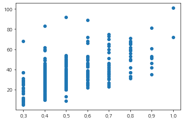

```python
plt.scatter(x='CO', y='PM10', data=df_raw)
```

산점도로 PM10와 CO의 관계를 확인해보니 CO가 증가할 수록 PM10이 증가하는 경향을 띠는 것을 확인할 수 있다.

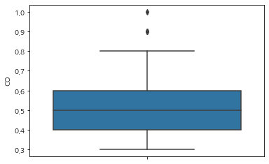

```python
sns.boxplot(y = 'CO', data = df_raw)
```

CO에서 이상치가 존재하기 때문에 결측치를 평균보다는 중앙값으로 채우는 것이 낫다고 판단하였다.

```python
df_raw.fillna(df_raw.median(), inplace=True)
print(df_raw.shape)
df_raw.isnull().sum()
```

```
(365, 14)
```

```
MeasDate     0
PM10         0
O3           0
NO2          0
CO           0
SO2          0
TEMP         0
RAIN         0
WIND         0
WIND_DIR     0
HUMIDITY     0
ATM_PRESS    0
SNOW         0
CLOUD        0
dtype: int64
```

```python
df_raw.describe()
```

|  | PM10 | O3 | NO2 | CO | SO2 | TEMP | RAIN | WIND | WIND_DIR | HUMIDITY | ATM_PRESS | SNOW | CLOUD |
| --- | --- | --- | --- | --- | --- | --- | --- | --- | --- | --- | --- | --- | --- |
| count | 365.00 | 3.65e+02 | 3.65e+02 | 365.00 | 3.65e+02 | 365.00 | 365.00 | 365.00 | 365.00 | 365.00 | 365.00 | 365.00 | 365.00 |
| mean | 33.42 | 2.36e-02 | 2.68e-02 | 0.51 | 3.03e-03 | 13.85 | 0.38 | 2.22 | 209.32 | 60.23 | 1005.87 | 0.02 | 5.06 |
| std | 15.94 | 1.19e-02 | 1.03e-02 | 0.14 | 6.32e-04 | 9.84 | 1.12 | 0.72 | 70.79 | 14.50 | 8.13 | 0.22 | 2.99 |
| min | 5.00 | 2.00e-03 | 8.00e-03 | 0.30 | 2.00e-03 | -7.95 | 0.00 | 0.94 | 50.00 | 17.90 | 983.80 | 0.00 | 0.00 |
| 25% | 22.00 | 1.40e-02 | 1.90e-02 | 0.40 | 3.00e-03 | 5.48 | 0.00 | 1.72 | 160.00 | 49.60 | 999.40 | 0.00 | 2.50 |
| 50% | 31.00 | 2.30e-02 | 2.50e-02 | 0.50 | 3.00e-03 | 13.87 | 0.00 | 2.09 | 221.00 | 61.00 | 1006.50 | 0.00 | 5.29 |
| 75% | 42.00 | 3.20e-02 | 3.40e-02 | 0.60 | 3.00e-03 | 23.10 | 0.10 | 2.62 | 266.00 | 69.80 | 1011.60 | 0.00 | 7.54 |
| max | 101.00 | 6.20e-02 | 5.90e-02 | 1.00 | 5.00e-03 | 31.72 | 11.80 | 5.88 | 351.00 | 95.00 | 1025.50 | 3.20 | 10.00 |

### 히스토그램

```
array([[<AxesSubplot:title={'center':'MeasDate'}>,
        <AxesSubplot:title={'center':'PM10'}>,
        <AxesSubplot:title={'center':'O3'}>,
        <AxesSubplot:title={'center':'NO2'}>],
       [<AxesSubplot:title={'center':'CO'}>,
        <AxesSubplot:title={'center':'SO2'}>,
        <AxesSubplot:title={'center':'TEMP'}>,
        <AxesSubplot:title={'center':'RAIN'}>],
       [<AxesSubplot:title={'center':'WIND'}>,
        <AxesSubplot:title={'center':'WIND_DIR'}>,
        <AxesSubplot:title={'center':'HUMIDITY'}>,
        <AxesSubplot:title={'center':'ATM_PRESS'}>],
       [<AxesSubplot:title={'center':'SNOW'}>,
        <AxesSubplot:title={'center':'CLOUD'}>, <AxesSubplot:>,
        <AxesSubplot:>]], dtype=object)
```

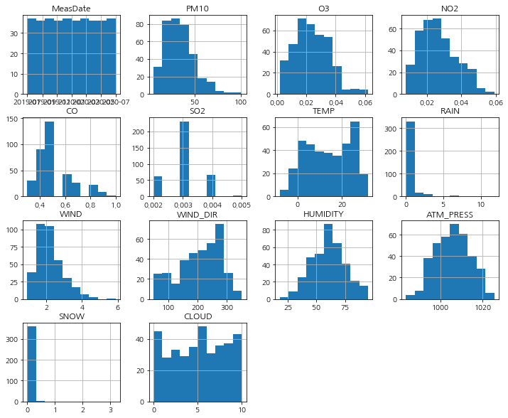

```python
df_raw.hist(figsize=(12,10))
```

- PM10과 분포가 비슷한 변수는 O3, NO2, WIND 정도로 보인다.
- RAIN, SNOW는 관련이 없어보인다.

### boxplot(이상치 처리)

미세먼지와 관련이 없어 보이는 날짜, 기압, 풍향을 제거한 후 boxplot을 그리려고 한다.

- 기압이 높아짐/낮아짐에 따라 미세먼지가 증감하지 않는다.
- 풍향의 각도가 높아짐/낮아짐에 따라 미세먼지가 증감하지 않는다.

```python
numerical_data=df_raw.iloc[:,1:13].columns
```

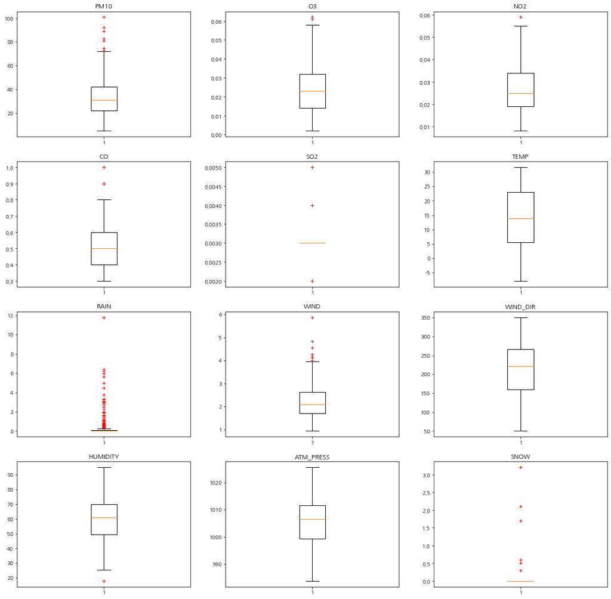

```python
fig,ax=plt.subplots(4,3,sharex=False,sharey=False)
fig.set_size_inches(20,20)
for i in range(len(numerical_data)):
    ax[i//3,i%3].boxplot(df_raw[numerical_data[i]],sym="r+")
    ax[i//3,i%3].set_title(numerical_data[i])
```

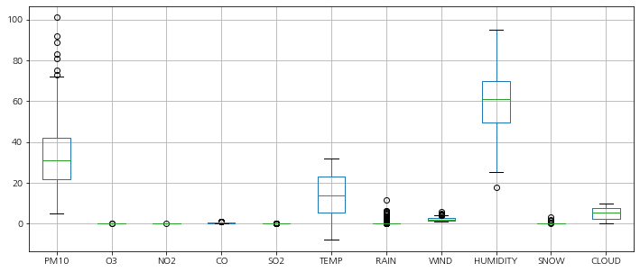

```python
df_raw_box = df_raw.drop(["MeasDate", "ATM_PRESS", "WIND_DIR"], axis=1, inplace=False)
df_raw_box.boxplot(figsize=(12,5))
```

이상치가 존재하기 때문에 이상치 처리를 해준다.

```python
def get_outlier(df=None, column=None, weight=1.5):
    quantile_25 = np.percentile(df[column].values, 25)
    quantile_75 = np.percentile(df[column].values, 75)

    IQR = quantile_75 - quantile_25
    IQR_weight = IQR*weight

    lowest = quantile_25 - IQR_weight
    highest = quantile_75 + IQR_weight

    outlier_idx = df[column][ (df[column] < lowest) | (df[column] > highest) ].index
    return outlier_idx
```

```python
cols = ["O3", "NO2", "CO", "WIND", "HUMIDITY"]
for col in cols:
    outlier_idx = get_outlier(df=df_raw, column=col, weight=1.5)
    df_raw.drop(outlier_idx, axis=0, inplace=True)
```

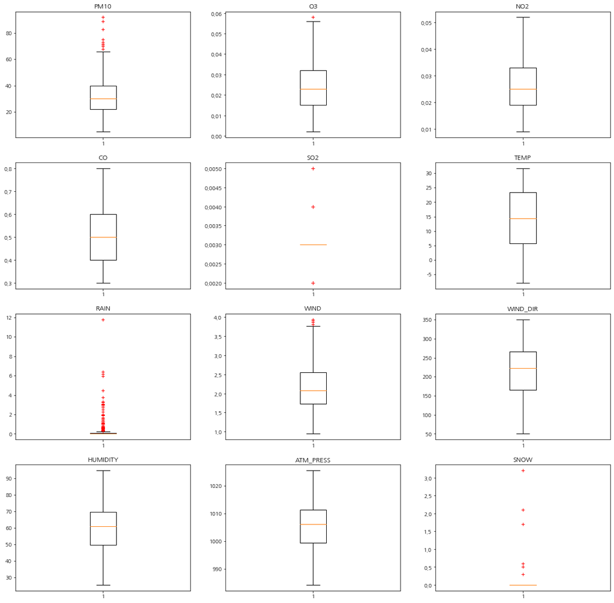

```python
fig,ax=plt.subplots(4,3,sharex=False,sharey=False)
fig.set_size_inches(20,20)
for i in range(len(numerical_data)):
    ax[i//3,i%3].boxplot(df_raw[numerical_data[i]],sym="r+")
    ax[i//3,i%3].set_title(numerical_data[i])
```

```python
df_raw
```

|  | MeasDate | PM10 | O3 | NO2 | CO | SO2 | TEMP | RAIN | WIND | WIND_DIR | HUMIDITY | ATM_PRESS | SNOW | CLOUD |
| --- | --- | --- | --- | --- | --- | --- | --- | --- | --- | --- | --- | --- | --- | --- |
| 0 | 2019-07-01 | 29.0 | 0.05 | 2.10e-02 | 0.5 | 3.00e-03 | 24.03 | 0.00 | 2.30 | 249 | 63.2 | 995.1 | 0.0 | 5.70 |
| 1 | 2019-07-02 | 26.0 | 0.05 | 2.00e-02 | 0.5 | 3.00e-03 | 24.29 | 0.00 | 2.26 | 265 | 63.2 | 998.6 | 0.0 | 3.83 |
| 2 | 2019-07-03 | 30.0 | 0.04 | 2.30e-02 | 0.4 | 3.00e-03 | 24.18 | 0.00 | 1.79 | 280 | 65.3 | 998.3 | 0.0 | 6.29 |
| 3 | 2019-07-04 | 28.0 | 0.03 | 2.60e-02 | 0.4 | 3.00e-03 | 25.35 | 0.00 | 2.04 | 263 | 58.6 | 996.6 | 0.0 | 2.54 |
| 4 | 2019-07-05 | 29.0 | 0.04 | 3.50e-02 | 0.5 | 3.00e-03 | 27.30 | 0.00 | 1.45 | 175 | 45.5 | 993.5 | 0.0 | 3.92 |
| ... | ... | ... | ... | ... | ... | ... | ... | ... | ... | ... | ... | ... | ... | ... |
| 360 | 2020-06-25 | 13.0 | 0.02 | 1.90e-02 | 0.5 | 3.00e-03 | 21.54 | 0.76 | 2.21 | 163 | 91.2 | 991.7 | 0.0 | 10.00 |
| 361 | 2020-06-26 | 19.0 | 0.04 | 1.60e-02 | 0.4 | 3.00e-03 | 21.66 | 0.41 | 3.12 | 228 | 84.0 | 996.0 | 0.0 | 8.73 |
| 362 | 2020-06-27 | 22.0 | 0.04 | 1.70e-02 | 0.4 | 4.00e-03 | 23.94 | 0.00 | 1.93 | 217 | 69.8 | 995.8 | 0.0 | 6.21 |
| 363 | 2020-06-28 | 27.0 | 0.04 | 9.00e-03 | 0.4 | 3.00e-03 | 25.03 | 0.00 | 2.35 | 283 | 71.3 | 994.7 | 0.0 | 2.63 |
| 364 | 2020-06-29 | 36.0 | 0.03 | 2.80e-02 | 0.6 | 3.00e-03 | 24.06 | 1.26 | 2.48 | 103 | 75.5 | 992.9 | 0.0 | 7.58 |

342 rows × 14 columns

```python
df
```

|  | PM10 | O3 | NO2 | CO | SO2 | TEMP | RAIN | WIND | WIND_DIR | HUMIDITY | ATM_PRESS | SNOW | CLOUD |
| --- | --- | --- | --- | --- | --- | --- | --- | --- | --- | --- | --- | --- | --- |
| 0 | 29.0 | 0.05 | 2.10e-02 | 0.5 | 3.00e-03 | 24.03 | 0.00 | 2.30 | 249 | 63.2 | 995.1 | 0.0 | 5.70 |
| 1 | 26.0 | 0.05 | 2.00e-02 | 0.5 | 3.00e-03 | 24.29 | 0.00 | 2.26 | 265 | 63.2 | 998.6 | 0.0 | 3.83 |
| 2 | 30.0 | 0.04 | 2.30e-02 | 0.4 | 3.00e-03 | 24.18 | 0.00 | 1.79 | 280 | 65.3 | 998.3 | 0.0 | 6.29 |
| 3 | 28.0 | 0.03 | 2.60e-02 | 0.4 | 3.00e-03 | 25.35 | 0.00 | 2.04 | 263 | 58.6 | 996.6 | 0.0 | 2.54 |
| 4 | 29.0 | 0.04 | 3.50e-02 | 0.5 | 3.00e-03 | 27.30 | 0.00 | 1.45 | 175 | 45.5 | 993.5 | 0.0 | 3.92 |
| ... | ... | ... | ... | ... | ... | ... | ... | ... | ... | ... | ... | ... | ... |
| 360 | 13.0 | 0.02 | 1.90e-02 | 0.5 | 3.00e-03 | 21.54 | 0.76 | 2.21 | 163 | 91.2 | 991.7 | 0.0 | 10.00 |
| 361 | 19.0 | 0.04 | 1.60e-02 | 0.4 | 3.00e-03 | 21.66 | 0.41 | 3.12 | 228 | 84.0 | 996.0 | 0.0 | 8.73 |
| 362 | 22.0 | 0.04 | 1.70e-02 | 0.4 | 4.00e-03 | 23.94 | 0.00 | 1.93 | 217 | 69.8 | 995.8 | 0.0 | 6.21 |
| 363 | 27.0 | 0.04 | 9.00e-03 | 0.4 | 3.00e-03 | 25.03 | 0.00 | 2.35 | 283 | 71.3 | 994.7 | 0.0 | 2.63 |
| 364 | 36.0 | 0.03 | 2.80e-02 | 0.6 | 3.00e-03 | 24.06 | 1.26 | 2.48 | 103 | 75.5 | 992.9 | 0.0 | 7.58 |

342 rows × 13 columns

이상치가 줄어든 것을 확인할 수 있다. (365개-> 342개)

### 표준화

```python
df_raw = df_raw.drop(columns='MeasDate')
```

```python
df_raw_y=df_raw[['PM10']]
df_raw_x=df_raw.drop(columns='PM10')
```

```python
df_raw_y=df_raw_y.reset_index()
```

```python
df_raw_x
```

|  | O3 | NO2 | CO | SO2 | TEMP | RAIN | WIND | WIND_DIR | HUMIDITY | ATM_PRESS | SNOW | CLOUD |
| --- | --- | --- | --- | --- | --- | --- | --- | --- | --- | --- | --- | --- |
| 0 | 0.05 | 2.10e-02 | 0.5 | 3.00e-03 | 24.03 | 0.00 | 2.30 | 249 | 63.2 | 995.1 | 0.0 | 5.70 |
| 1 | 0.05 | 2.00e-02 | 0.5 | 3.00e-03 | 24.29 | 0.00 | 2.26 | 265 | 63.2 | 998.6 | 0.0 | 3.83 |
| 2 | 0.04 | 2.30e-02 | 0.4 | 3.00e-03 | 24.18 | 0.00 | 1.79 | 280 | 65.3 | 998.3 | 0.0 | 6.29 |
| 3 | 0.03 | 2.60e-02 | 0.4 | 3.00e-03 | 25.35 | 0.00 | 2.04 | 263 | 58.6 | 996.6 | 0.0 | 2.54 |
| 4 | 0.04 | 3.50e-02 | 0.5 | 3.00e-03 | 27.30 | 0.00 | 1.45 | 175 | 45.5 | 993.5 | 0.0 | 3.92 |
| ... | ... | ... | ... | ... | ... | ... | ... | ... | ... | ... | ... | ... |
| 360 | 0.02 | 1.90e-02 | 0.5 | 3.00e-03 | 21.54 | 0.76 | 2.21 | 163 | 91.2 | 991.7 | 0.0 | 10.00 |
| 361 | 0.04 | 1.60e-02 | 0.4 | 3.00e-03 | 21.66 | 0.41 | 3.12 | 228 | 84.0 | 996.0 | 0.0 | 8.73 |
| 362 | 0.04 | 1.70e-02 | 0.4 | 4.00e-03 | 23.94 | 0.00 | 1.93 | 217 | 69.8 | 995.8 | 0.0 | 6.21 |
| 363 | 0.04 | 9.00e-03 | 0.4 | 3.00e-03 | 25.03 | 0.00 | 2.35 | 283 | 71.3 | 994.7 | 0.0 | 2.63 |
| 364 | 0.03 | 2.80e-02 | 0.6 | 3.00e-03 | 24.06 | 1.26 | 2.48 | 103 | 75.5 | 992.9 | 0.0 | 7.58 |

342 rows × 12 columns

```python
df_raw

# StandardScaler 적용
scaler = StandardScaler()
df_scaled_ = scaler.fit(df_raw_x)
df_scaled1_ = df_scaled_.transform(df_raw_x)
df_scaled1_ = pd.DataFrame(df_scaled1_, columns=df_raw_x.columns)
df_scaled1_
```

|  | O3 | NO2 | CO | SO2 | TEMP | RAIN | WIND | WIND_DIR | HUMIDITY | ATM_PRESS | SNOW | CLOUD |
| --- | --- | --- | --- | --- | --- | --- | --- | --- | --- | --- | --- | --- |
| 0 | 2.65 | -0.58 | -0.04 | -0.03 | 1.00 | -0.33 | 0.19 | 0.53 | 0.21 | -1.34 | -0.11 | 0.23 |
| 1 | 2.56 | -0.69 | -0.04 | -0.03 | 1.02 | -0.33 | 0.13 | 0.77 | 0.21 | -0.90 | -0.11 | -0.39 |
| 2 | 1.60 | -0.37 | -0.85 | -0.03 | 1.01 | -0.33 | -0.63 | 0.99 | 0.36 | -0.94 | -0.11 | 0.43 |
| 3 | 0.89 | -0.05 | -0.85 | -0.03 | 1.13 | -0.33 | -0.22 | 0.74 | -0.11 | -1.15 | -0.11 | -0.82 |
| 4 | 1.86 | 0.89 | -0.04 | -0.03 | 1.33 | -0.33 | -1.17 | -0.54 | -1.03 | -1.54 | -0.11 | -0.36 |
| ... | ... | ... | ... | ... | ... | ... | ... | ... | ... | ... | ... | ... |
| 337 | -0.07 | -0.79 | -0.04 | -0.03 | 0.75 | 0.38 | 0.05 | -0.72 | 2.17 | -1.76 | -0.11 | 1.67 |
| 338 | 1.33 | -1.11 | -0.85 | -0.03 | 0.76 | 0.05 | 1.51 | 0.23 | 1.66 | -1.23 | -0.11 | 1.24 |
| 339 | 1.77 | -1.00 | -0.85 | 1.58 | 0.99 | -0.33 | -0.40 | 0.07 | 0.67 | -1.25 | -0.11 | 0.40 |
| 340 | 1.77 | -1.84 | -0.85 | -0.03 | 1.10 | -0.33 | 0.27 | 1.03 | 0.78 | -1.39 | -0.11 | -0.79 |
| 341 | 0.19 | 0.16 | 0.77 | -0.03 | 1.00 | 0.84 | 0.48 | -1.59 | 1.07 | -1.61 | -0.11 | 0.86 |

342 rows × 12 columns

```python
df_final = pd.concat([df_raw_y, df_scaled1_], axis=1)
df_final
```

|  | index | PM10 | O3 | NO2 | CO | SO2 | TEMP | RAIN | WIND | WIND_DIR | HUMIDITY | ATM_PRESS | SNOW | CLOUD |
| --- | --- | --- | --- | --- | --- | --- | --- | --- | --- | --- | --- | --- | --- | --- |
| 0 | 0 | 29.0 | 2.65 | -0.58 | -0.04 | -0.03 | 1.00 | -0.33 | 0.19 | 0.53 | 0.21 | -1.34 | -0.11 | 0.23 |
| 1 | 1 | 26.0 | 2.56 | -0.69 | -0.04 | -0.03 | 1.02 | -0.33 | 0.13 | 0.77 | 0.21 | -0.90 | -0.11 | -0.39 |
| 2 | 2 | 30.0 | 1.60 | -0.37 | -0.85 | -0.03 | 1.01 | -0.33 | -0.63 | 0.99 | 0.36 | -0.94 | -0.11 | 0.43 |
| 3 | 3 | 28.0 | 0.89 | -0.05 | -0.85 | -0.03 | 1.13 | -0.33 | -0.22 | 0.74 | -0.11 | -1.15 | -0.11 | -0.82 |
| 4 | 4 | 29.0 | 1.86 | 0.89 | -0.04 | -0.03 | 1.33 | -0.33 | -1.17 | -0.54 | -1.03 | -1.54 | -0.11 | -0.36 |
| ... | ... | ... | ... | ... | ... | ... | ... | ... | ... | ... | ... | ... | ... | ... |
| 337 | 360 | 13.0 | -0.07 | -0.79 | -0.04 | -0.03 | 0.75 | 0.38 | 0.05 | -0.72 | 2.17 | -1.76 | -0.11 | 1.67 |
| 338 | 361 | 19.0 | 1.33 | -1.11 | -0.85 | -0.03 | 0.76 | 0.05 | 1.51 | 0.23 | 1.66 | -1.23 | -0.11 | 1.24 |
| 339 | 362 | 22.0 | 1.77 | -1.00 | -0.85 | 1.58 | 0.99 | -0.33 | -0.40 | 0.07 | 0.67 | -1.25 | -0.11 | 0.40 |
| 340 | 363 | 27.0 | 1.77 | -1.84 | -0.85 | -0.03 | 1.10 | -0.33 | 0.27 | 1.03 | 0.78 | -1.39 | -0.11 | -0.79 |
| 341 | 364 | 36.0 | 0.19 | 0.16 | 0.77 | -0.03 | 1.00 | 0.84 | 0.48 | -1.59 | 1.07 | -1.61 | -0.11 | 0.86 |

342 rows × 14 columns

```python
# 데이터 분할
df_scaled_train, df_scaled_test = train_test_split(df_final, test_size=0.3)
print("train data X size : {}".format(df_scaled_train.shape))
print("test data X size : {}".format(df_scaled_test.shape))
```

```
train data X size : (239, 14)
test data X size : (103, 14)
```

### 산점도

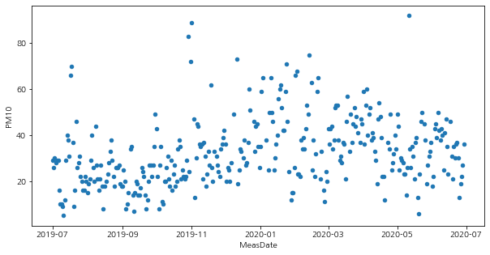

```python
df_raw.plot.scatter(x="MeasDate", y="PM10", figsize=(10,5))
```

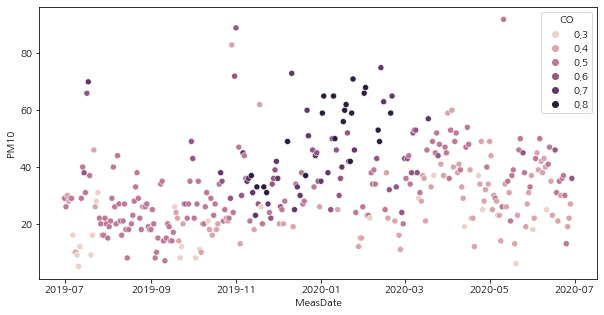

```python
fig = plt.figure(figsize=(10,5))
sns.scatterplot(x="MeasDate", y="PM10", hue="CO", data=df_raw)
```

- 산점도로 CO와 PM10의 관계를 확인해 보면 CO가 높을수록 PM10이 높은 경향이 있다.

### 시계열도표

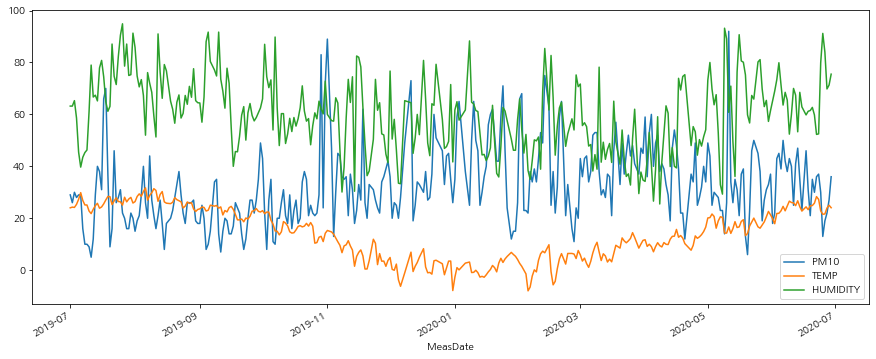

```python
df_raw.plot.line(y=["PM10", "TEMP", "HUMIDITY"], x="MeasDate", figsize=(15,6))
```

### 여러 변수간의 산점도

[figure not shown]

```python
sns.pairplot(data=df_raw)
```

여기서 미세먼지와 관련이 커 보이는 변수들끼리 그래프를 나타내면 다음과 같다.

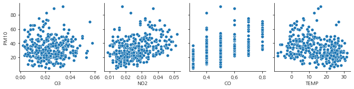

```python
sns.pairplot(data=df_raw, x_vars=["O3", "NO2", "CO", "TEMP"], y_vars="PM10")
```

### 상관계수 히트맵

```python
df_corr = df_raw.corr()
```

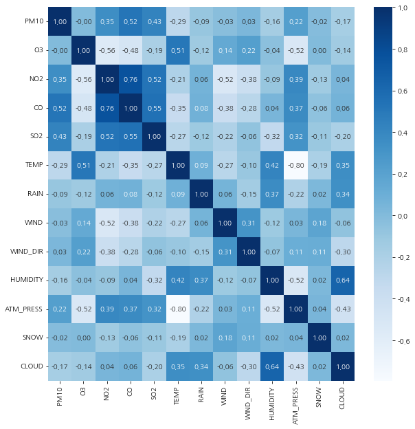

```python
fig, ax = plt.subplots(figsize=(10,10))
sns.heatmap(df_corr, annot=True, fmt=".2f", cmap="Blues", ax=ax)
plt.show()
```

```python
df_corr.sort_values(by=['PM10']).round(2)
```

|  | PM10 | O3 | NO2 | CO | SO2 | TEMP | RAIN | WIND | WIND_DIR | HUMIDITY | ATM_PRESS | SNOW | CLOUD |
| --- | --- | --- | --- | --- | --- | --- | --- | --- | --- | --- | --- | --- | --- |
| TEMP | -0.29 | 0.51 | -0.21 | -0.35 | -0.27 | 1.00 | 0.09 | -0.27 | -0.10 | 0.42 | -0.80 | -0.19 | 0.35 |
| CLOUD | -0.17 | -0.14 | 0.04 | 0.06 | -0.20 | 0.35 | 0.34 | -0.06 | -0.30 | 0.64 | -0.43 | 0.02 | 1.00 |
| HUMIDITY | -0.16 | -0.04 | -0.09 | 0.04 | -0.32 | 0.42 | 0.37 | -0.12 | -0.07 | 1.00 | -0.52 | 0.02 | 0.64 |
| RAIN | -0.09 | -0.12 | 0.06 | 0.08 | -0.12 | 0.09 | 1.00 | 0.06 | -0.15 | 0.37 | -0.22 | 0.02 | 0.34 |
| WIND | -0.03 | 0.14 | -0.52 | -0.38 | -0.22 | -0.27 | 0.06 | 1.00 | 0.31 | -0.12 | 0.03 | 0.18 | -0.06 |
| SNOW | -0.02 | 0.00 | -0.13 | -0.06 | -0.11 | -0.19 | 0.02 | 0.18 | 0.11 | 0.02 | 0.04 | 1.00 | 0.02 |
| O3 | -0.00 | 1.00 | -0.56 | -0.48 | -0.19 | 0.51 | -0.12 | 0.14 | 0.22 | -0.04 | -0.52 | 0.00 | -0.14 |
| WIND_DIR | 0.03 | 0.22 | -0.38 | -0.28 | -0.06 | -0.10 | -0.15 | 0.31 | 1.00 | -0.07 | 0.11 | 0.11 | -0.30 |
| ATM_PRESS | 0.22 | -0.52 | 0.39 | 0.37 | 0.32 | -0.80 | -0.22 | 0.03 | 0.11 | -0.52 | 1.00 | 0.04 | -0.43 |
| NO2 | 0.35 | -0.56 | 1.00 | 0.76 | 0.52 | -0.21 | 0.06 | -0.52 | -0.38 | -0.09 | 0.39 | -0.13 | 0.04 |
| SO2 | 0.43 | -0.19 | 0.52 | 0.55 | 1.00 | -0.27 | -0.12 | -0.22 | -0.06 | -0.32 | 0.32 | -0.11 | -0.20 |
| CO | 0.52 | -0.48 | 0.76 | 1.00 | 0.55 | -0.35 | 0.08 | -0.38 | -0.28 | 0.04 | 0.37 | -0.06 | 0.06 |
| PM10 | 1.00 | -0.00 | 0.35 | 0.52 | 0.43 | -0.29 | -0.09 | -0.03 | 0.03 | -0.16 | 0.22 | -0.02 | -0.17 |

NO2, SO2, CO와 PM10의 상관계수가 높은 것을 확인할 수 있다.

## 회귀분석

- 데이터 구성은 2.1~2.2 에서 수행하였음.

```python
# qqplot, 회귀분석의 상수항 추가
from statsmodels.api import qqplot, add_constant

# 행렬 연산
import numpy as np
```

```python
reg_model = smf.ols(formula= "PM10 ~ O3 + NO2 + CO + SO2 + TEMP + RAIN + WIND + WIND_DIR + \
                    HUMIDITY + ATM_PRESS + CLOUD", data=df_scaled_train)

reg_result = reg_model.fit()
print(reg_result.summary())
```

```
                            OLS Regression Results
==============================================================================
Dep. Variable:                   PM10   R-squared:                       0.519
Model:                            OLS   Adj. R-squared:                  0.495
Method:                 Least Squares   F-statistic:                     22.25
Date:                Mon, 30 May 2022   Prob (F-statistic):           1.80e-30
Time:                        22:59:16   Log-Likelihood:                -879.21
No. Observations:                 239   AIC:                             1782.
Df Residuals:                     227   BIC:                             1824.
Df Model:                          11
Covariance Type:            nonrobust
==============================================================================
                 coef    std err          t      P>|t|      [0.025      0.975]
------------------------------------------------------------------------------
Intercept     32.7526      0.641     51.124      0.000      31.490      34.015
O3             6.9691      1.096      6.356      0.000       4.809       9.129
NO2            4.5586      1.443      3.160      0.002       1.716       7.401
CO             8.4431      1.257      6.718      0.000       5.967      10.919
SO2            0.3404      0.866      0.393      0.695      -1.366       2.047
TEMP          -5.8947      1.366     -4.315      0.000      -8.586      -3.203
RAIN          -1.0733      0.647     -1.658      0.099      -2.349       0.202
WIND           2.4419      0.878      2.783      0.006       0.713       4.171
WIND_DIR       1.8785      0.791      2.375      0.018       0.320       3.437
HUMIDITY      -1.2604      1.116     -1.129      0.260      -3.460       0.939
ATM_PRESS     -4.3541      1.357     -3.209      0.002      -7.028      -1.680
CLOUD          0.3159      0.944      0.335      0.738      -1.544       2.176
==============================================================================
Omnibus:                       54.592   Durbin-Watson:                   1.805
Prob(Omnibus):                  0.000   Jarque-Bera (JB):              124.787
Skew:                           1.070   Prob(JB):                     8.00e-28
Kurtosis:                       5.821   Cond. No.                         5.71
==============================================================================

Notes:
[1] Standard Errors assume that the covariance matrix of the errors is correctly specified.
```

```python
# p값이 0.05보다 큰 변수를 하나씩 반복적으로 제거한 결과

reg_model = smf.ols(formula= "PM10 ~ O3 + NO2 + CO + TEMP + RAIN + WIND + WIND_DIR + ATM_PRESS", data=df_scaled_train)

reg_result = reg_model.fit()
print(reg_result.summary())
```

```
                            OLS Regression Results
==============================================================================
Dep. Variable:                   PM10   R-squared:                       0.515
Model:                            OLS   Adj. R-squared:                  0.498
Method:                 Least Squares   F-statistic:                     30.51
Date:                Mon, 30 May 2022   Prob (F-statistic):           2.78e-32
Time:                        23:02:07   Log-Likelihood:                -880.17
No. Observations:                 239   AIC:                             1778.
Df Residuals:                     230   BIC:                             1810.
Df Model:                           8
Covariance Type:            nonrobust
==============================================================================
                 coef    std err          t      P>|t|      [0.025      0.975]
------------------------------------------------------------------------------
Intercept     32.7755      0.636     51.508      0.000      31.522      34.029
O3             7.5011      0.950      7.898      0.000       5.630       9.372
NO2            5.1959      1.341      3.874      0.000       2.553       7.838
CO             8.1086      1.124      7.212      0.000       5.893      10.324
TEMP          -6.3526      1.281     -4.958      0.000      -8.877      -3.828
RAIN          -1.2528      0.626     -2.001      0.047      -2.486      -0.019
WIND           2.5315      0.864      2.930      0.004       0.829       4.234
WIND_DIR       1.7649      0.745      2.368      0.019       0.296       3.233
ATM_PRESS     -3.9877      1.251     -3.188      0.002      -6.452      -1.523
==============================================================================
Omnibus:                       47.228   Durbin-Watson:                   1.828
Prob(Omnibus):                  0.000   Jarque-Bera (JB):               97.695
Skew:                           0.968   Prob(JB):                     6.11e-22
Kurtosis:                       5.462   Cond. No.                         5.10
==============================================================================

Notes:
[1] Standard Errors assume that the covariance matrix of the errors is correctly specified.
```

O3 + NO2 + CO + TEMP + RAIN + WIND + WIND_DIR + ATM_PRESS 변수를 남겼을 때, p value가 0.05 이하인 것을 확인할 수 있다.

### 다중공선성

```python
df_train_x = df_train[["O3", "NO2", "CO", "TEMP", "RAIN", "WIND", "WIND_DIR", "ATM_PRESS"]]
df_train_x_const = add_constant(df_train_x)

df_vif = pd.DataFrame()
df_vif["variable"] = df_train_x_const.columns
df_vif["VIF"] = [variance_inflation_factor(df_train_x_const.values, i) for i in range(df_train_x_const.shape[1])]

df_vif.sort_values("VIF", inplace=True)
df_vif.round(3)
```

|  | variable | VIF |
| --- | --- | --- |
| 5 | RAIN | 1.22 |
| 7 | WIND_DIR | 1.40 |
| 6 | WIND | 2.02 |
| 1 | O3 | 2.23 |
| 3 | CO | 2.89 |
| 2 | NO2 | 3.85 |
| 8 | ATM_PRESS | 4.03 |
| 4 | TEMP | 4.41 |
| 0 | const | 64079.57 |

-> VIF가 10 이상인 변수가 없으므로 다중공선성이 없다.

### 등분산성

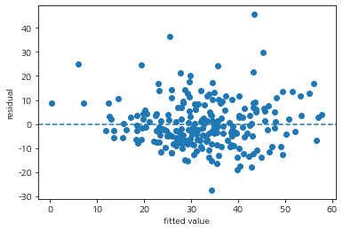

```python
plt.scatter(reg_result.fittedvalues, reg_result.resid)
plt.xlabel("fitted value")
plt.ylabel("residual")
plt.axhline(y = 0, linestyle = "--")
```

-> 잔차가 y=0을 기준으로 랜덤하게 산포되어 있으므로 등분산성 만족

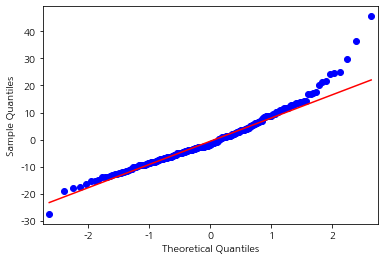

[figure not shown]

```python
qqplot(reg_result.resid, line = "q")
```

### 독립성

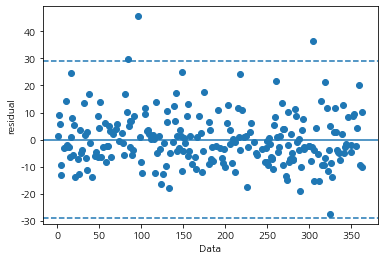

```python
plt.scatter(df_train.index, reg_result.resid, marker="o")
plt.xlabel("Data")
plt.ylabel("residual")
plt.axhline(y = 0, linestyle = "-")
plt.axhline(y = 3*np.std(reg_result.resid), linestyle="--")
plt.axhline(y = -3*np.std(reg_result.resid), linestyle="--")
```

```python
train_pred = reg_result.predict(df_scaled_train)
test_pred = reg_result.predict(df_scaled_test)
print("train data의 결정계수:", r2_score(df_scaled_train['PM10'], train_pred))
print("test data의 결정계수:", r2_score(df_scaled_test['PM10'], test_pred))
```

```
train data의 결정계수: 0.5148897035348362
test data의 결정계수: 0.40543104248242146
```

## 의사결정 트리

```python
import pandas as pd

import matplotlib.pyplot as plt
import matplotlib

from sklearn.tree import export_graphviz

import graphviz

from sklearn.model_selection import train_test_split
from sklearn.tree import DecisionTreeRegressor

from sklearn.model_selection import GridSearchCV
```

### 데이터 구성하기

```python
df_raw_y = df_raw["PM10"]
df_raw_x = df_raw.drop(["PM10"], axis=1, inplace=False)

df_train_x, df_test_x, df_train_y, df_test_y = train_test_split(df_raw_x, df_raw_y, test_size = 0.3)

print("train data X size: {}".format(df_train_x.shape))
print("train data Y size: {}".format(df_train_y.shape))
print("test data X size: {}".format(df_test_x.shape))
print("test data Y size: {}".format(df_train_y.shape))
```

```
train data X size: (239, 12)
train data Y size: (239,)
test data X size: (103, 12)
test data Y size: (239,)
```

### 모델 Parameter 선택

```python
# min_samples_leaf: 잎사귀 최소 자료 수
para_leaf = [n_leaf * 1 for n_leaf in range(5, 15)]

# min_samples_split: 분리 노드의 최소 자료 수
para_split = [n_split * 2 for n_split in range(10, 18)]

# min_samples_split: 분리 노드의 최소 자료 수
para_depth = [depth for depth in range(4, 9)]
```

```python
estimator = DecisionTreeRegressor()

# 구하고자 하는 parameter와 범위
param_grid = {"criterion": ["mse", "friedman_mse", "mae"], "max_features": ["auto", "sqrt", "log2"],
              "max_depth": para_depth, "min_samples_split": para_split, "min_samples_leaf": para_leaf}

# 설명력이 높은 최적 parameter 찾기
grid_dt = GridSearchCV(estimator, param_grid, scoring = "r2", n_jobs = -1)
grid_dt.fit(df_train_x, df_train_y)

print("best estimator model: \n{}".format(grid_dt.best_estimator_))
print("\nbest parameter: \n{}".format(grid_dt.best_params_))
print("\nbest score: \n{}".format(grid_dt.best_score_))
```

```
best estimator model:
DecisionTreeRegressor(max_depth=8, max_features='log2', min_samples_leaf=14,
                      min_samples_split=26)

best parameter:
{'criterion': 'mse', 'max_depth': 8, 'max_features': 'log2', 'min_samples_leaf': 14, 'min_samples_split': 26}

best score:
0.26900127207476376
```

### 모델 학습

```python
tree_final = DecisionTreeRegressor(min_samples_leaf=14, min_samples_split=26, max_depth=8)
tree_final.fit(df_train_x, df_train_y)
```

```
DecisionTreeRegressor(max_depth=8, min_samples_leaf=14, min_samples_split=26)
```

```python
df_y_pred = tree_final.predict(df_test_x)
# 예측 모델의 score
print("train score:", tree_final.score(df_train_x, df_train_y))
print("test score:", tree_final.score(df_test_x, df_test_y))
```

```
train score: 0.5805842158006373
test score: 0.049901926492996074
```

```python
v_feature_name = df_train_x.columns
export_graphviz(tree_final, out_file="tree_final.dot", feature_names=v_feature_name, impurity=True, filled=True)

with open("tree_final.dot") as f:
    dot_graph = f.read()
display(graphviz.Source(dot_graph))
```

[figure not shown]

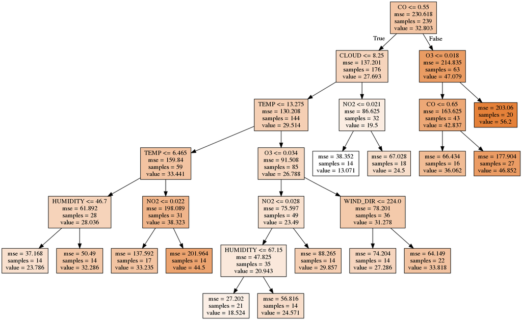

```python
graphviz.Source(dot_graph).render('tree5', format="png") # --> 이미지로 저장



from IPython.display import Image

Image('./tree5.png')
```

-> 트리 분리에 영향이 큰 변수: CO, CLOUD, O3, NO2, TEMP

```python
# 변수명 저장
v_feature_name = df_train_x.columns

# tree.feature_importances_로 설명변수 중요도 확인 및 테이블로 저장
df_importance = pd.DataFrame()
df_importance["Feature"] = v_feature_name
df_importance["Importance"] = tree_final.feature_importances_

# df_feature_importance의 테이블을 중요도별로 정렬
df_importance.sort_values("Importance", ascending=False, inplace=True)
df_importance.round(2)
```

|  | Feature | Importance |
| --- | --- | --- |
| 2 | CO | 0.58 |
| 0 | O3 | 0.12 |
| 4 | TEMP | 0.10 |
| 1 | NO2 | 0.09 |
| 11 | CLOUD | 0.08 |
| 8 | HUMIDITY | 0.03 |
| 7 | WIND_DIR | 0.01 |
| 3 | SO2 | 0.00 |
| 5 | RAIN | 0.00 |
| 6 | WIND | 0.00 |
| 9 | ATM_PRESS | 0.00 |
| 10 | SNOW | 0.00 |

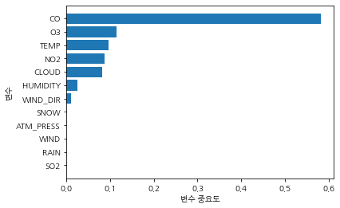

```python
# 설명변수 중요도 그래프
# 중요도가 높은 변수를 상위에 그림
df_importance.sort_values("Importance", ascending=True, inplace=True)
coordinates = range(len(df_importance))
plt.barh(y=coordinates, width=df_importance["Importance"])
plt.yticks(coordinates, df_importance["Feature"])
plt.xlabel("변수 중요도")
plt.ylabel("변수")
```

## 랜덤 포레스트

```python
import pandas as pd

import matplotlib.pyplot as plt
import matplotlib

from sklearn.tree import export_graphviz

import graphviz

from sklearn.model_selection import train_test_split
from sklearn.ensemble import RandomForestRegressor

from sklearn.model_selection import GridSearchCV
```

```python
rf_uncustomized = RandomForestRegressor()
rf_uncustomized.fit(df_train_x, df_train_y)

# Train, Test 데이터 설명력
print("Score on training set: {:.3f}".format(rf_uncustomized.score(df_train_x, df_train_y)))
print("Score on test set: {:.3f}".format(rf_uncustomized.score(df_test_x, df_test_y)))
```

```
Score on training set: 0.926
Score on test set: 0.273
```

```python
rf_uncustomized
```

[output not shown]

#### GridSearchCV를 이용한 최적 parameter 찾기

```python
estimator = RandomForestRegressor(random_state=1234)

# 구하고자 하는 parameter와 범위
param_grid = {"max_depth": para_depth, "min_samples_split": para_split, "min_samples_leaf": para_leaf}

# 설명력이 높은 최적 parameter 찾기
grid_rf = GridSearchCV(estimator, param_grid, scoring = "r2", n_jobs = -1)
grid_rf.fit(df_train_x, df_train_y)

print("best estimator model: \n{}".format(grid_rf.best_estimator_))
print("\nbest parameter: \n{}".format(grid_rf.best_params_))
print("\nbest score: \n{}".format(grid_rf.best_score_))
```

```
best estimator model:
RandomForestRegressor(max_depth=8, min_samples_leaf=5, min_samples_split=20,
                      random_state=1234)

best parameter:
{'max_depth': 8, 'min_samples_leaf': 5, 'min_samples_split': 20}

best score:
0.4375110876477688
```

```python
rf_final = RandomForestRegressor(n_estimators=100, min_samples_leaf=5, min_samples_split=20, max_depth=8)
rf_final.fit(df_train_x, df_train_y)

# Train, Test 데이터 설명력
print("Score on training set: {:.3f}".format(rf_final.score(df_train_x, df_train_y)))
print("Score on test set: {:.3f}".format(rf_final.score(df_test_x, df_test_y)))
```

```
Score on training set: 0.668
Score on test set: 0.207
```

[figure not shown]

[figure not shown]

```python
# 변수명 저장
v_feature_name = df_train_x.columns

# 0번 트리
export_graphviz(rf_final.estimators_[0], out_file="rfr_final_0.dot", feature_names=v_feature_name, impurity=True, filled=True)

# tree_final_0.dot 그리기
with open("rfr_final_0.dot") as f:
    dot_graph = f.read()
display(graphviz.Source(dot_graph))

graphviz.Source(dot_graph).render('rf', format="png") # --> 이미지로 저장

from IPython.display import Image

Image('./tree5.png')
```

```python
# tree.feature_importance_로 설명변수 중요도 확인 및 테이블로 저장
df_importance = pd.DataFrame()
df_importance["Feature"] = v_feature_name
df_importance["Importance"] = rf_final.feature_importances_

# df_feature_importance의 테이블을 중요도 순으로 정렬
df_importance.sort_values("Importance", ascending=False, inplace=True)
df_importance.round(3)
```

|  | Feature | Importance |
| --- | --- | --- |
| 2 | CO | 0.43 |
| 0 | O3 | 0.12 |
| 4 | TEMP | 0.08 |
| 1 | NO2 | 0.08 |
| 11 | CLOUD | 0.07 |
| 7 | WIND_DIR | 0.06 |
| 6 | WIND | 0.05 |
| 9 | ATM_PRESS | 0.04 |
| 8 | HUMIDITY | 0.04 |
| 3 | SO2 | 0.01 |
| 5 | RAIN | 0.01 |
| 10 | SNOW | 0.00 |

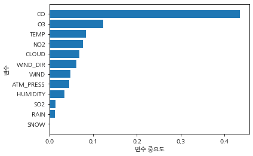

```python
# 설명변수 중요도 그래프
# 중요도가 높은 변수를 상위에 그림
df_importance.sort_values("Importance", ascending=True, inplace=True)
coordinates = range(len(df_importance))
plt.barh(y=coordinates, width=df_importance["Importance"])
plt.yticks(coordinates, df_importance["Feature"])
plt.xlabel("변수 중요도")
plt.ylabel("변수")
```

## 그래디언트 부스팅

```python
import pandas as pd

import matplotlib.pyplot as plt
import matplotlib

from sklearn.tree import export_graphviz

import graphviz
### 모델 Parameter 조정
from sklearn.model_selection import train_test_split
from sklearn.ensemble import GradientBoostingRegressor

from sklearn.model_selection import GridSearchCV
```

```python
gb_uncustomized = GradientBoostingRegressor()
gb_uncustomized.fit(df_train_x, df_train_y)

# Train, Test 데이터 설명력
print("Score on training set: {:.3f}".format(gb_uncustomized.score(df_train_x, df_train_y)))
print("Score on test set: {:.3f}".format(gb_uncustomized.score(df_test_x, df_test_y)))
```

```
Score on training set: 0.932
Score on test set: 0.325
```

### 모델 Parameter 조정

#### 트리 수

```python
# train, test 설명력 결과 저장
train_score = []
test_score = []

# n_estimatos: 트리 수 변경(1~100)
para_n_tree = [n_tree * 10 for n_tree in range(1, 11)]

for v_n_estimators in para_n_tree:
    gb = GradientBoostingRegressor(n_estimators=v_n_estimators, random_state=1234)
    gb.fit(df_train_x, df_train_y)
    train_score.append(gb.score(df_train_x, df_train_y))
    test_score.append(gb.score(df_test_x, df_test_y))

# 결과 저장
df_score_n = pd.DataFrame()
df_score_n["n_estimators"] = para_n_tree
df_score_n["TrainScore"] = train_score
df_score_n["TestScore"] = test_score#### 트리 수
```

```python
# 모델 설명력 확인
df_score_n.round(3)
```

|  | n_estimators | TrainScore | TestScore |
| --- | --- | --- | --- |
| 0 | 10 | 0.52 | 0.23 |
| 1 | 20 | 0.70 | 0.30 |
| 2 | 30 | 0.77 | 0.30 |
| 3 | 40 | 0.81 | 0.31 |
| 4 | 50 | 0.84 | 0.31 |
| 5 | 60 | 0.87 | 0.32 |
| 6 | 70 | 0.89 | 0.31 |
| 7 | 80 | 0.91 | 0.32 |
| 8 | 90 | 0.92 | 0.32 |
| 9 | 100 | 0.93 | 0.32 |

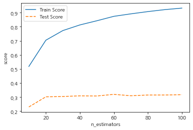

```python
# 모델 설명력 그래프 확인
plt.plot(para_n_tree, train_score, linestyle = "-", label = "Train Score")
plt.plot(para_n_tree, test_score, linestyle = "--", label = "Test Score")
plt.ylabel("score")
plt.xlabel("n_estimators")
plt.legend()
```

#### 잎사귀 노드의 최소 자료 수

```python
# train, test 설명력 결과 저장
train_score = []
test_score = []

# min_samples_leaf: 잎사귀 최소 자료 수
para_leaf = [n_leaf * 1 for n_leaf in range(1, 21)]

for v_min_samples_leaf in para_leaf:
    gb = GradientBoostingRegressor(n_estimators=60, random_state=1234, min_samples_leaf=v_min_samples_leaf)
    gb.fit(df_train_x, df_train_y)
    train_score.append(gb.score(df_train_x, df_train_y))
    test_score.append(gb.score(df_test_x, df_test_y))

# 결과 저장
df_score_leaf = pd.DataFrame()
df_score_leaf["MinSamplesLeaf"] = para_leaf
df_score_leaf["TrainScore"] = train_score
df_score_leaf["TestScore"] = test_score
```

```python
# 모델 설명력 확인
df_score_leaf.round(3)
```

|  | MinSamplesLeaf | TrainScore | TestScore |
| --- | --- | --- | --- |
| 0 | 1 | 0.87 | 0.32 |
| 1 | 2 | 0.88 | 0.33 |
| 2 | 3 | 0.86 | 0.32 |
| 3 | 4 | 0.86 | 0.35 |
| 4 | 5 | 0.86 | 0.34 |
| 5 | 6 | 0.85 | 0.33 |
| 6 | 7 | 0.86 | 0.31 |
| 7 | 8 | 0.84 | 0.33 |
| 8 | 9 | 0.84 | 0.32 |
| 9 | 10 | 0.83 | 0.31 |
| 10 | 11 | 0.83 | 0.32 |
| 11 | 12 | 0.82 | 0.32 |
| 12 | 13 | 0.81 | 0.31 |
| 13 | 14 | 0.80 | 0.30 |
| 14 | 15 | 0.80 | 0.32 |
| 15 | 16 | 0.80 | 0.31 |
| 16 | 17 | 0.79 | 0.30 |
| 17 | 18 | 0.78 | 0.29 |
| 18 | 19 | 0.78 | 0.28 |
| 19 | 20 | 0.78 | 0.32 |

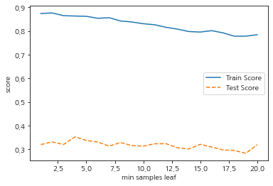

```python
# 모델 설명력 그래프 확인
plt.plot(para_leaf, train_score, linestyle = "-", label = "Train Score")
plt.plot(para_leaf, test_score, linestyle = "--", label = "Test Score")
plt.ylabel("score")
plt.xlabel("min samples leaf")
plt.legend()
```

#### 분리 노드의 최소 자료 수

```python
# train, test 설명력 결과 저장
train_score = []
test_score = []

# min_samples_split: 분할하기 위한 노드의 최소 자료 수
para_split = [n_split * 2 for n_split in range(1, 21)]

for v_min_samples_split in para_split:
    gb = GradientBoostingRegressor(n_estimators=60, random_state=1234, min_samples_leaf=4, min_samples_split=v_min_samples_split)
    gb.fit(df_train_x, df_train_y)
    train_score.append(gb.score(df_train_x, df_train_y))
    test_score.append(gb.score(df_test_x, df_test_y))

# 결과 저장
df_score_split = pd.DataFrame()
df_score_split["MinSamplesSplit"] = para_split
df_score_split["TrainScore"] = train_score
df_score_split["TestScore"] = test_score#### 분리 노드의 최소 자료 수
```

```python
# 모델 설명력 확인
df_score_split.round(3)
```

|  | MinSamplesSplit | TrainScore | TestScore |
| --- | --- | --- | --- |
| 0 | 2 | 0.86 | 0.35 |
| 1 | 4 | 0.86 | 0.35 |
| 2 | 6 | 0.86 | 0.35 |
| 3 | 8 | 0.86 | 0.35 |
| 4 | 10 | 0.86 | 0.34 |
| 5 | 12 | 0.85 | 0.35 |
| 6 | 14 | 0.86 | 0.35 |
| 7 | 16 | 0.85 | 0.33 |
| 8 | 18 | 0.85 | 0.35 |
| 9 | 20 | 0.84 | 0.34 |
| 10 | 22 | 0.84 | 0.34 |
| 11 | 24 | 0.83 | 0.35 |
| 12 | 26 | 0.82 | 0.34 |
| 13 | 28 | 0.83 | 0.34 |
| 14 | 30 | 0.83 | 0.34 |
| 15 | 32 | 0.82 | 0.34 |
| 16 | 34 | 0.83 | 0.34 |
| 17 | 36 | 0.81 | 0.35 |
| 18 | 38 | 0.81 | 0.34 |
| 19 | 40 | 0.81 | 0.34 |

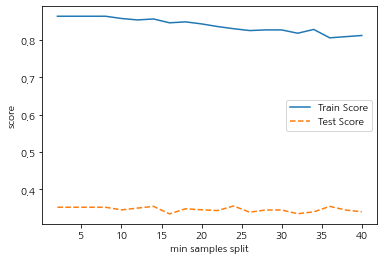

```python
# 모델 설명력 그래프 확인
plt.plot(para_split, train_score, linestyle = "-", label = "Train Score")
plt.plot(para_split, test_score, linestyle = "--", label = "Test Score")
plt.ylabel("score")
plt.xlabel("min samples split")
plt.legend()
```

#### 최대 깊이

```python
# train, test 설명력 결과 저장
train_score = []
test_score = []

# max_depth: 최대 깊이 변경
para_depth = [depth for depth in range(1, 11)]

for v_max_depth in para_depth:
    gb = GradientBoostingRegressor(n_estimators=60, random_state=1234, min_samples_leaf=4, min_samples_split=8, max_depth=v_max_depth)
    gb.fit(df_train_x, df_train_y)
    train_score.append(gb.score(df_train_x, df_train_y))
    test_score.append(gb.score(df_test_x, df_test_y))

# 결과 저장
df_score_depth = pd.DataFrame()
df_score_depth["Depth"] = para_depth
df_score_depth["TrainScore"] = train_score
df_score_depth["TestScore"] = test_score#### 최대 깊이
```

```python
# 모델 설명력 확인
df_score_depth.round(3)
```

|  | Depth | TrainScore | TestScore |
| --- | --- | --- | --- |
| 0 | 1 | 0.50 | 0.20 |
| 1 | 2 | 0.72 | 0.29 |
| 2 | 3 | 0.86 | 0.35 |
| 3 | 4 | 0.94 | 0.33 |
| 4 | 5 | 0.97 | 0.28 |
| 5 | 6 | 0.99 | 0.25 |
| 6 | 7 | 0.99 | 0.25 |
| 7 | 8 | 1.00 | 0.25 |
| 8 | 9 | 1.00 | 0.24 |
| 9 | 10 | 1.00 | 0.23 |

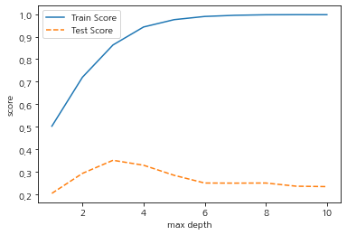

```python
# 모델 설명력 그래프 확인
plt.plot(para_depth, train_score, linestyle = "-", label = "Train Score")
plt.plot(para_depth, test_score, linestyle = "--", label = "Test Score")
plt.ylabel("score")
plt.xlabel("max depth")
plt.legend()
```

#### 학습률

```python
# train, test 설명력 결과 저장
train_score = []
test_score = []

# learning rate: 학습률 변경
para_lr = [lr * 0.1 for lr in range(1, 10)]

for v_learning_rate in para_lr:
    gb = GradientBoostingRegressor(n_estimators=60, random_state=1234, min_samples_leaf=4, min_samples_split=8, max_depth=3, learning_rate=v_learning_rate)
    gb.fit(df_train_x, df_train_y)
    train_score.append(gb.score(df_train_x, df_train_y))
    test_score.append(gb.score(df_test_x, df_test_y))

# 결과 저장
df_score_lr = pd.DataFrame()
df_score_lr["Leraning Rate"] = para_lr
df_score_lr["TrainScore"] = train_score
df_score_lr["TestScore"] = test_score
```

```python
# 모델 설명력 확인
df_score_lr.round(3)
```

|  | Leraning Rate | TrainScore | TestScore |
| --- | --- | --- | --- |
| 0 | 0.1 | 0.86 | 0.35 |
| 1 | 0.2 | 0.94 | 0.29 |
| 2 | 0.3 | 0.97 | 0.27 |
| 3 | 0.4 | 0.98 | 0.24 |
| 4 | 0.5 | 0.99 | 0.16 |
| 5 | 0.6 | 0.99 | 0.23 |
| 6 | 0.7 | 1.00 | 0.12 |
| 7 | 0.8 | 1.00 | 0.04 |
| 8 | 0.9 | 1.00 | -0.01 |

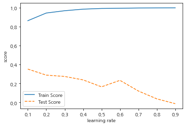

```python
# 모델 설명력 그래프 확인
plt.plot(para_lr, train_score, linestyle = "-", label = "Train Score")
plt.plot(para_lr, test_score, linestyle = "--", label = "Test Score")
plt.ylabel("score")
plt.xlabel("learning rate")
plt.legend()
```

### 최종 모델 선정

```python
gb_final = GradientBoostingRegressor(n_estimators=60, min_samples_leaf=4, min_samples_split=8, max_depth=3, learning_rate=0.2)
gb_final.fit(df_train_x, df_train_y)

# Train, Test 데이터 설명력
print("Score on training set: {:.3f}".format(gb_final.score(df_train_x, df_train_y)))
print("Score on test set: {:.3f}".format(gb_final.score(df_test_x, df_test_y)))
```

```
Score on training set: 0.944
Score on test set: 0.282
```

```python
# 변수명 저장
v_feature_name = df_train_x.columns

# tree.feature_importances_로 설명변수 중요도 확인 및 테이블로 저장
df_importance = pd.DataFrame()
df_importance["Feature"] = v_feature_name
df_importance["Importance"] = gb_final.feature_importances_

# df_feature_importance의 테이블을 중요도별로 정렬
df_importance.sort_values("Importance", ascending=False, inplace=True)
df_importance.round(2)
```

|  | Feature | Importance |
| --- | --- | --- |
| 2 | CO | 0.35 |
| 0 | O3 | 0.15 |
| 1 | NO2 | 0.11 |
| 4 | TEMP | 0.10 |
| 11 | CLOUD | 0.08 |
| 7 | WIND_DIR | 0.06 |
| 6 | WIND | 0.05 |
| 8 | HUMIDITY | 0.03 |
| 9 | ATM_PRESS | 0.03 |
| 5 | RAIN | 0.03 |
| 3 | SO2 | 0.00 |
| 10 | SNOW | 0.00 |

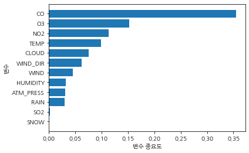

```python
# 설명변수 중요도 그래프
# 중요도가 높은 변수를 상위에 그림
df_importance.sort_values("Importance", ascending=True, inplace=True)
coordinates = range(len(df_importance))
plt.barh(y=coordinates, width=df_importance["Importance"])
plt.yticks(coordinates, df_importance["Feature"])
plt.xlabel("변수 중요도")
plt.ylabel("변수")
```

## 영향인자 선정 및 결과 해석

### 모델 평가

```python
import pandas as pd
import numpy as np

import statsmodels.formula.api as smf

from sklearn.tree import DecisionTreeRegressor
from sklearn.ensemble import RandomForestRegressor
from sklearn.ensemble import GradientBoostingRegressor

from sklearn.metrics import mean_squared_error
from sklearn.metrics import mean_absolute_error
```

```python
# RMSE: root mean squared error 함수
def root_mean_squared_error(y_true, y_pred):
    return np.sqrt(mean_squared_error(y_true, y_pred))

# MAPE: mean absolute percentage error 함수
def mean_absolute_percentage_error(y_true, y_pred):
    return np.mean(np.abs((y_true - y_pred) / y_true)) * 100
```

```python
# 회귀모델
reg_model = smf.ols(formula= "PM10 ~ O3 + NO2 + CO + TEMP + RAIN + WIND + WIND_DIR + ATM_PRESS", data=df_scaled_train)
reg_result = reg_model.fit()
print(reg_result.summary())

# Decision Tree
dt_model = DecisionTreeRegressor(min_samples_leaf=14, min_samples_split=26, max_depth=8)
dt_model.fit(df_train_x, df_train_y)

# Random Forest
rf_model = RandomForestRegressor(n_estimators=100, min_samples_leaf=4, min_samples_split=4, max_depth=10)
rf_model.fit(df_train_x, df_train_y)

# Gradient Boosting
gb_model = GradientBoostingRegressor(random_state=1234, n_estimators=60, min_samples_leaf=4, min_samples_split=8, max_depth=3, learning_rate=0.2)
gb_model.fit(df_train_x, df_train_y)
```

```
                            OLS Regression Results
==============================================================================
Dep. Variable:                   PM10   R-squared:                       0.515
Model:                            OLS   Adj. R-squared:                  0.498
Method:                 Least Squares   F-statistic:                     30.51
Date:                Mon, 30 May 2022   Prob (F-statistic):           2.78e-32
Time:                        23:12:25   Log-Likelihood:                -880.17
No. Observations:                 239   AIC:                             1778.
Df Residuals:                     230   BIC:                             1810.
Df Model:                           8
Covariance Type:            nonrobust
==============================================================================
                 coef    std err          t      P>|t|      [0.025      0.975]
------------------------------------------------------------------------------
Intercept     32.7755      0.636     51.508      0.000      31.522      34.029
O3             7.5011      0.950      7.898      0.000       5.630       9.372
NO2            5.1959      1.341      3.874      0.000       2.553       7.838
CO             8.1086      1.124      7.212      0.000       5.893      10.324
TEMP          -6.3526      1.281     -4.958      0.000      -8.877      -3.828
RAIN          -1.2528      0.626     -2.001      0.047      -2.486      -0.019
WIND           2.5315      0.864      2.930      0.004       0.829       4.234
WIND_DIR       1.7649      0.745      2.368      0.019       0.296       3.233
ATM_PRESS     -3.9877      1.251     -3.188      0.002      -6.452      -1.523
==============================================================================
Omnibus:                       47.228   Durbin-Watson:                   1.828
Prob(Omnibus):                  0.000   Jarque-Bera (JB):               97.695
Skew:                           0.968   Prob(JB):                     6.11e-22
Kurtosis:                       5.462   Cond. No.                         5.10
==============================================================================

Notes:
[1] Standard Errors assume that the covariance matrix of the errors is correctly specified.
```

```
GradientBoostingRegressor(learning_rate=0.2, min_samples_leaf=4,
                          min_samples_split=8, n_estimators=60,
                          random_state=1234)
```

```python
# 모델 리스트, 그래프를 그리기 생성 목적
models = ["회귀분석", "의사결정나무", "랜덤 포레스트", "그래디언트 부스팅"]

# 평가 리스트 초기화
mse, rmse, mae, mape = [], [], [], []
```

```python
df_scaled_test_x
```

|  | index | PM10 | O3 | NO2 | CO | SO2 | TEMP | RAIN | WIND | WIND_DIR | HUMIDITY | ATM_PRESS | SNOW | CLOUD |
| --- | --- | --- | --- | --- | --- | --- | --- | --- | --- | --- | --- | --- | --- | --- |
| 338 | 361 | 19.0 | 1.33 | -1.11 | -0.85 | -0.03 | 0.76 | 0.05 | 1.51 | 0.23 | 1.66 | -1.23e+00 | -0.11 | 1.24 |
| 161 | 169 | 30.0 | -1.30 | 0.68 | 1.58 | -0.03 | -0.60 | 2.71 | 0.21 | -0.21 | 1.44 | -7.33e-02 | -0.11 | 1.52 |
| 240 | 257 | 37.0 | 0.45 | -1.11 | -0.85 | -0.03 | -1.12 | -0.33 | 1.31 | 0.74 | -0.96 | 1.90e-03 | -0.11 | -1.19 |
| 13 | 13 | 40.0 | 3.00 | -0.90 | -0.04 | -0.03 | 1.17 | -0.33 | -0.85 | 0.75 | 0.35 | -1.69e+00 | -0.11 | -0.31 |
| 40 | 40 | 21.0 | 0.28 | -0.26 | -0.04 | -0.03 | 1.75 | -0.33 | -1.01 | -1.71 | -0.06 | -1.21e+00 | -0.11 | 0.15 |
| ... | ... | ... | ... | ... | ... | ... | ... | ... | ... | ... | ... | ... | ... | ... |
| 171 | 181 | 45.0 | -1.39 | 0.89 | 0.77 | 1.58 | -1.09 | -0.14 | 1.12 | -2.09 | -0.74 | 1.22e+00 | -0.11 | 1.14 |
| 237 | 254 | 29.0 | 0.28 | -1.11 | -1.66 | -0.03 | -1.06 | -0.33 | 2.12 | 0.91 | -1.30 | 1.27e-01 | -0.11 | -1.67 |
| 62 | 63 | 25.0 | 0.63 | 0.37 | -0.04 | -0.03 | 1.03 | -0.33 | -1.07 | 0.81 | -0.23 | 1.02e-01 | -0.11 | 0.82 |
| 219 | 234 | 59.0 | -1.39 | 2.15 | 2.39 | -0.03 | -1.00 | -0.33 | -0.66 | -0.92 | 0.16 | 2.07e+00 | -0.11 | -0.75 |
| 279 | 300 | 25.0 | 0.89 | -1.74 | -1.66 | -0.03 | -0.19 | -0.33 | 1.35 | 1.10 | -1.11 | 8.96e-02 | -0.11 | -1.16 |

103 rows × 14 columns

```python
df_test_y
```

```
329    45.0
348    47.0
201    60.0
28     16.0
316    34.0
       ...
106    16.0
166    34.0
265    37.0
5      29.0
153    36.0
Name: PM10, Length: 103, dtype: float64
```

```python
# 예측
lr_y_pred = reg_result.predict(df_scaled_test.drop(["PM10", "index"],axis=1))

# 평가
mse.append(mean_squared_error(df_test_y, lr_y_pred))
rmse.append(root_mean_squared_error(df_test_y, lr_y_pred))
mae.append(mean_absolute_error(df_test_y, lr_y_pred))
mape.append(mean_absolute_percentage_error(df_test_y, lr_y_pred))

print(mse, rmse, mae, mape)
```

```
[329.079142789789] [18.140538657652616] [14.180923646430918] [32.2542777003081]
```

```python
# 예측
dt_y_pred = dt_model.predict(df_test_x)

# 평가
mse.append(mean_squared_error(df_test_y, dt_y_pred))
rmse.append(root_mean_squared_error(df_test_y, dt_y_pred))
mae.append(mean_absolute_error(df_test_y, dt_y_pred))
mape.append(mean_absolute_percentage_error(df_test_y, dt_y_pred))

print(mse, rmse, mae, mape)
```

```
[329.079142789789, 184.42506039355055] [18.140538657652616, 13.580318861998439] [14.180923646430918, 10.471225986717139] [32.2542777003081, 40.78468763403938]
```

```python
# 예측
rf_y_pred = rf_model.predict(df_test_x)

# 평가
mse.append(mean_squared_error(df_test_y, rf_y_pred))
rmse.append(root_mean_squared_error(df_test_y, rf_y_pred))
mae.append(mean_absolute_error(df_test_y, rf_y_pred))
mape.append(mean_absolute_percentage_error(df_test_y, rf_y_pred))

print(mse, rmse, mae, mape)
```

```
[329.079142789789, 184.42506039355055, 151.4523924745777] [18.140538657652616, 13.580318861998439, 12.306599549614738] [14.180923646430918, 10.471225986717139, 8.862665194757449] [32.2542777003081, 40.78468763403938, 31.98707646611721]
```

```python
# 예측
gb_y_pred = gb_model.predict(df_test_x)

# 평가
mse.append(mean_squared_error(df_test_y, gb_y_pred))
rmse.append(root_mean_squared_error(df_test_y, gb_y_pred))
mae.append(mean_absolute_error(df_test_y, gb_y_pred))
mape.append(mean_absolute_percentage_error(df_test_y, gb_y_pred))

print(mse, rmse, mae, mape)
```

[output not shown]

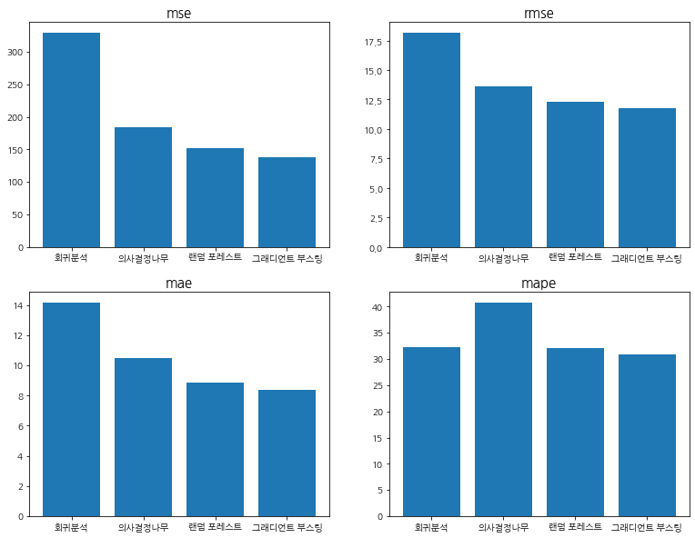

```python
fig, ax = plt.subplots(2, 2, figsize=(13, 10))
ax[0, 0].bar(models, mse)
ax[0, 0].set_title("mse").set_fontsize(15)

ax[0, 1].bar(models, rmse)
ax[0, 1].set_title("rmse").set_fontsize(15)

ax[1, 0].bar(models, mae)
ax[1, 0].set_title("mae").set_fontsize(15)

ax[1, 1].bar(models, mape)
ax[1, 1].set_title("mape").set_fontsize(15)
```